# simon-5501-06-slides

2026-09-29

## Topics to be covered

- What you will learn
  - Diagnostic plots
  - R code for diagnostic plots
  - Influence measures
  - R code for influence measures
  - Log transformations
  - R code for log transformations
  - Your homework

## The population model

- $Y_i=\beta_0+\beta_1 X_i + \epsilon_i,\ i=1,...,N$
  - $\epsilon_i$ is an unknown random variable
    - Mean 0, standard deviation, $\sigma$
    - Often assumed to be normal
  - $\beta_0$ and $\beta_1$ are unknown parameters
  - $b_0$ and $b_1$ are estimates from the sample

## Violations of this model

- Nonlinearity
- Heterogeneity
- Non-normality
- Lack of independence

## Using residuals for diagnostic plots

- $\epsilon_i$ is unknown, but $e_i$ is known
  - $\epsilon_i=Y_i-(\beta_0+\beta_1 X_i)$
  - $e_i=Y_i-(b_0+b_1 X_i)$
  - Are there problems with the $e_i$
    - Indirect evidence of problems with the $\epsilon_i$
- Residuals show patterns more clearly than the original data

## Diagnosing non-linearity, 1

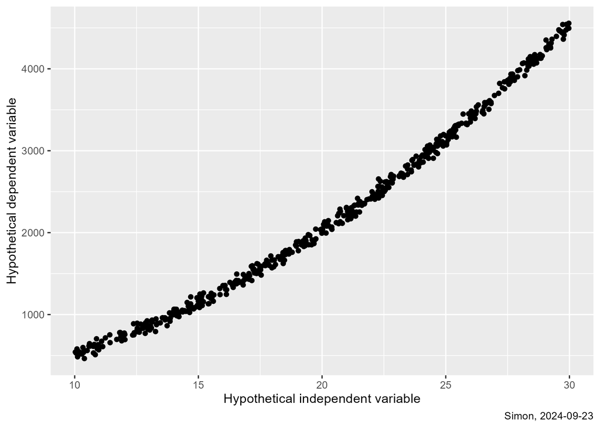

## Diagnosing non-linearity, 2

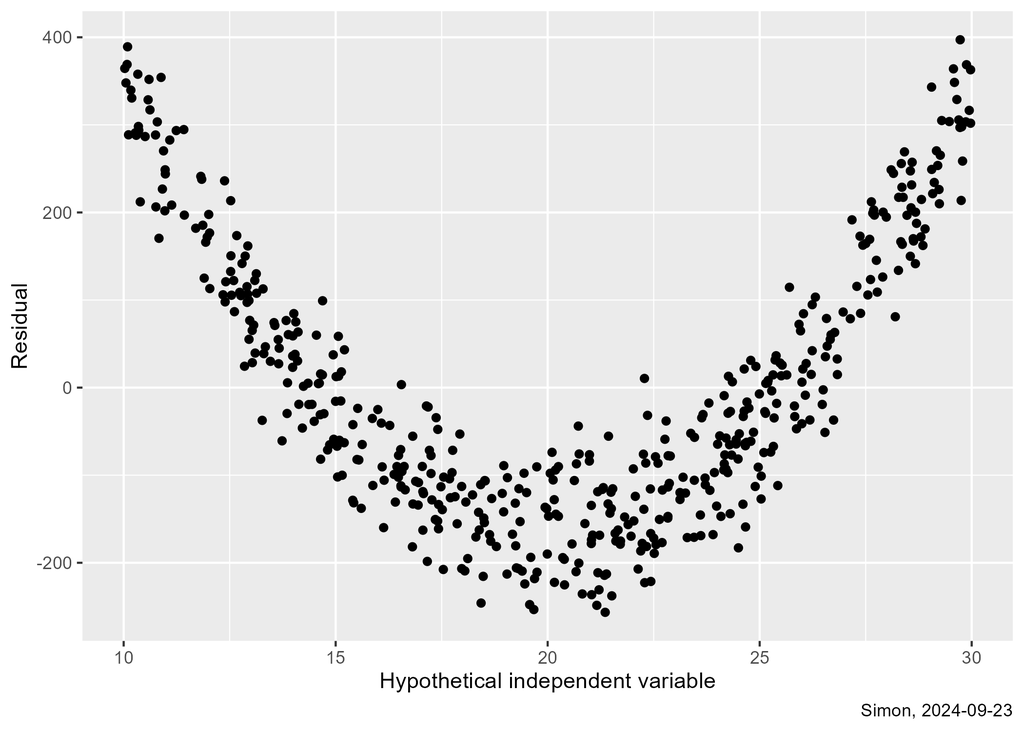

## Remedies for non-linearity

- Largely beyond the scope of this class
  - Ignore the non-linearity
  - Add a quadratic term
  - Consider a non-linear model
  - Use a spline model

## Diagnosing heterogeneity, 1

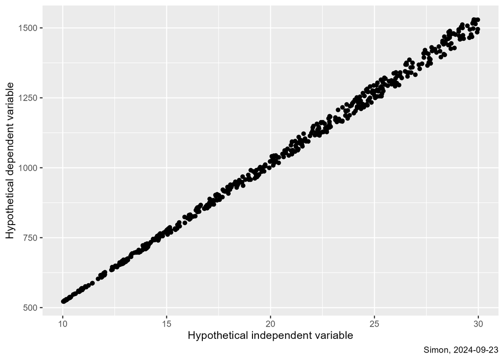

## Diagnosing heterogeneity, 2

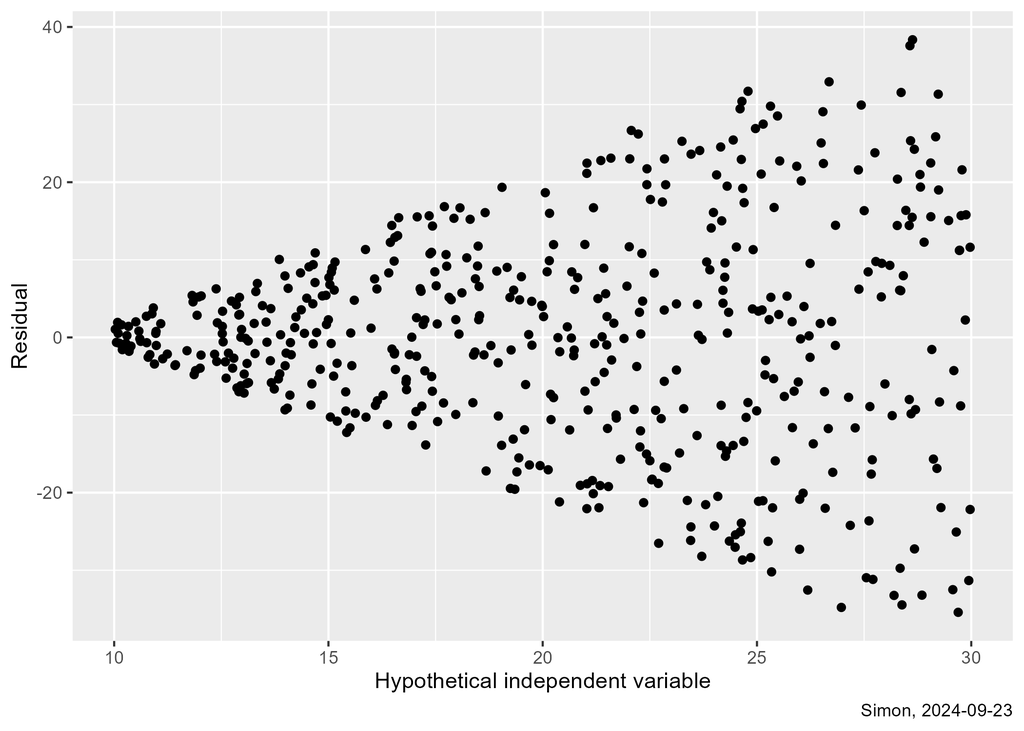

## Remedies for heterogeneity

- Ignore the heterogeneity
- Log transformation
  - Especially useful if larger values have more variation
- Weighted regression

## Diagnosing non-normality, 1

- Independent variable (X), non-normality is okay
- Dependent variable (Y), non-normality is okay
- Population residual ($\epsilon$), non-normality is not okay
  - Confidence intervals, hypothesis tests not valid
  - Less of a concern with large sample sizes

## Diagnosing non-normality, 2

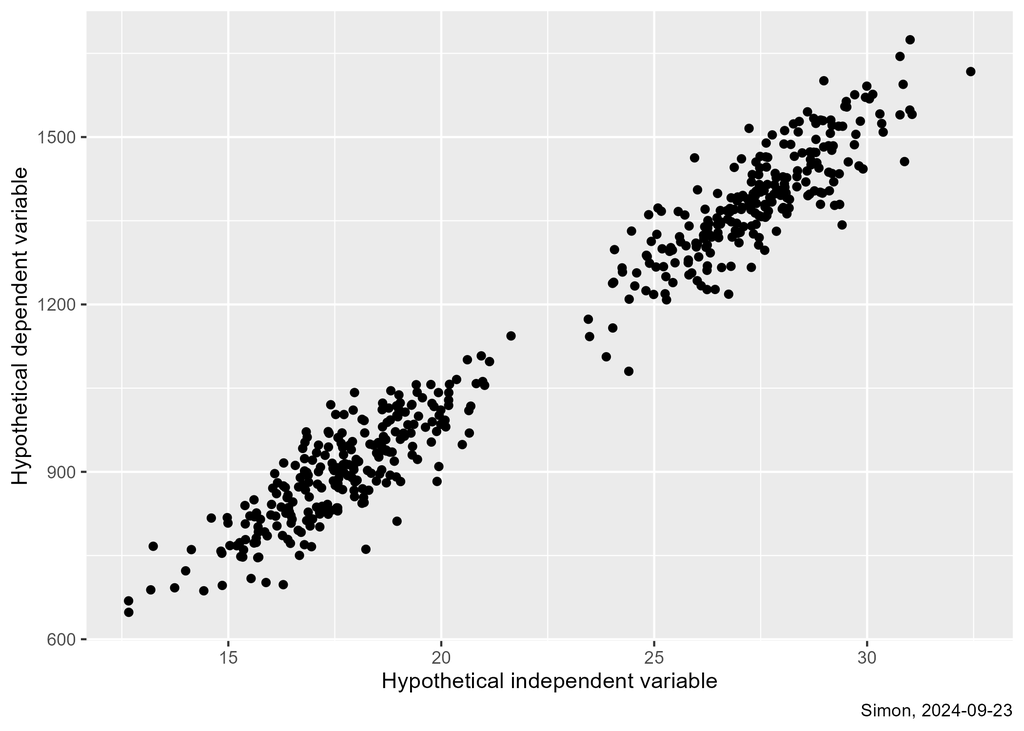

## Diagnosing non-normality, 2

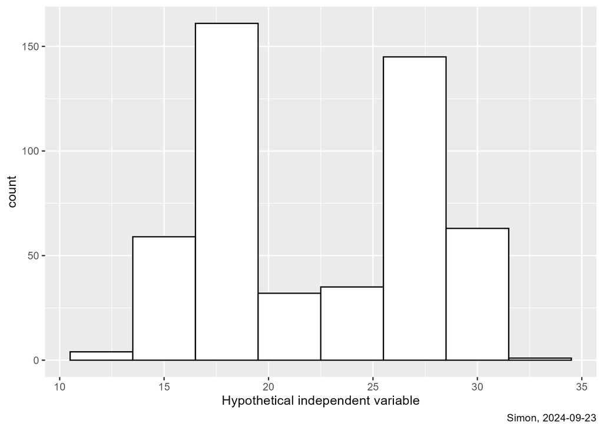

## Diagnosing non-normality, 3

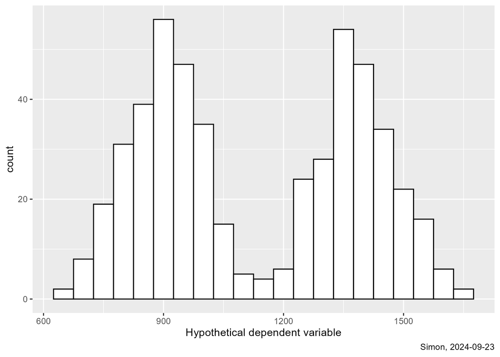

## Diagnosing non-normality, 4

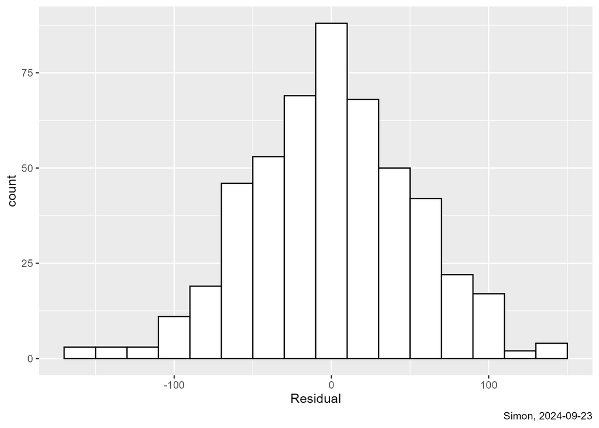

## Remedies for non-normality

- Ignore the non-normality
  - Large sample sizes
  - Certain types of non-normality
- Log transformation
  - Especially useful for right-skewed data
- Generalized linear models

## Lack of independence

- Often judged qualitatively
- Clustering
  - Litter effects
  - Family members
  - Clinic effects
  - Multi-center trials
- Infectious diseases
- Time sequence effects

## General thoughts on assumption tests

- Don’t over-interpret small departures from assumptions
- Normality is not an important assumption with large sample sizes
- A violation of assumptions is actually an opportunity
  - A more complex model could greatly improve things
- Linear regression is always okay as a descriptive tool

## Break #1

- What you have learned
  - Diagnostic plots
- What’s coming next
  - R code for diagnostic plots

## Live demo, part 1

- This section uses - a program, simon-5501-06-demo.qmd - a data set, [albuquerque-housing,csv](https://github.com/pmean/datasets/blob/master/albuquerque-housing.csv) - with a data dictionary, albuquerque-housing.yaml

## Break #2

- What you have learned
  - R code for diagnostic plots
- What’s coming next
  - Influence measures

## Influence measures

- Does one data point dominate the regression fit?
  - Extreme in the X direction
  - Deviation from the trend line
- Influential data points are NOT a violation of assumptions

## Studentized deleted residual

- $\hat{Y}_{(i)}$ is the predicted value of Y at $X = X_i$ using all the data except $(X_i,Y_i)$
- $e_{(i)} = \hat{Y}_{(i)}-Y_i$ is the deleted residual
- $se(e_{(i)})$ is the standard error
  - or, the estimated standard deviation of the deleted residual
- $e_{(i)} / se(e_{(i)})$ is the studentized deleted residual
  - Investigate if > +3 or < -3

## Leverage

- $h_{ii}=\frac{1}{n}+\frac{(X_i-\bar{X})^2}{\Sigma(X_j-\bar{X})^2}$
  - Investigate if > 3*2/n

## Cook’s distance

- $D_i=\frac{\Sigma(\hat{Y}_j-\hat{Y}_{j(i)})^2}{(k+1)\sqrt{MSE}}$
  - where k is the number of independent variables
  - investigate if > 1

## Break #3

- What you have learned
  - Influence measures
- What’s coming next
  - R code for influence measures

## Live demo, part 2

- This section is a continuation of the demo. It uses the same files.
  - simon-5501-06-demo.qmd
  - albuquerque-housing,csv
  - albuquerque-housing.yaml

## Break #4

- What you have learned
  - R code for influence measures
- What’s coming next
  - Log transformations

## The log transformation

- Useful for correcting non-normality
  - Only if skewed right
- Useful for correcting heterogeneity
  - Only when larger values have larger variation

## Which logarithm?

- Natural logarithm, $ln$, or $log_e$
  - R function is just log()
  - Difficult to interptet
  - Simple from a mathematics perspective
- Base 10 logarithm, $log_{10}$
  - R function is log10()
  - Easiest to interpret, powers of 10
- Base 2 logarithm, $log_2$ - R function is log2() - Powers of 2, common in genomics

## Back transformation, 1

- Puts regression coefficients back on original scale
- Antilog inverts log
  - exp() inverts log()
  - 10^ inverts log10()
  - 2^ inverts log2()

## Back transformation, 2

- $Y_i^*=log_{10}(Y_i)$ or $log_2{Y_i}$ or $ln(Y_i)$
- $\hat{Y}_i^* = b_0^* + b_1^* X_i$
- $b_0 = antilog(b_0^*)$
  - Estimated average value of Y when X=0
  - Actually a geometric mean

## Back transformation, 3

- $b_1 = antilog(b_1^*)$
  - Estimated average relative change in Y when X increases by one unit
  - 1.1 represents a 10% increase
  - 0.9 represents a 10% decrease

## Break #5

- What you have learned
  - Log transformations
- What’s coming next
  - R code for log transformations

## Live demo, part 3

- This section is another continuation of the demo. It uses the same files.:
  - simon-5501-06-demo.qmd
  - albuquerque-housing,csv
  - albuquerque-housing.yaml

## Break #6

- What you have learned
  - R code for log transformations
- What’s coming next
  - Your homework

## Your homework

- simon-5501-06-directions.md

## Summary

- What you have learned
  - Diagnostic plots
  - R code for diagnostic plots
  - Influence measures
  - R code for influence measures
  - Log transformations
  - R code for log transformations
  - Your homework